# ML

We are multiplying:

- **Matrix A**: size ( n , k )
- **Matrix B**: size ( k , m )

The result will be **Matrix C**: size ( n , m ).

### **How each element is computed**

Each element ($ C_{ij}$ ) is calculated as: $$ C_{ij} = \sum_{t=1}^{k} A_{it} \cdot B_{tj} $$

This means:

- **Multiplications per element**: k
- **Additions per element**: k - 1

### **Total operations**

Since there are ($n \times m$) elements in the result:

$$ \text{Total multiplications} = n \times m \times k $$

$$ \text{Total additions} = n \times m \times (k - 1) $$

**Final Answer:**

- Multiplications: ( $n \times m \times k $)
- Additions: ( $n \times m \times (k - 1) $)

### QUESTION 2

#### Write Python code to multiply the above two matrices. Solve using list of lists and then use numpy. Compare the timing of both solutions. Which one is faster? Why?

```python
import random
import time
import numpy as np
#Matrix dimension
n, k, m = 100, 200, 300

mat_A = [[random.randint(1, 100) for _ in range(k)] for _ in range(n)]
mat_B = [[random.randint(1, 100) for _ in range(m)] for _ in range(k)]
# mat_C = [[random.randint(1, 100) for _ in range(3)] for _ in range(4)]
# print(mat_C)
# mat_C = [[0 for_in randge(m)] for_in range(n)]
mat_C = [[0 for _ in range(m)] for _ in range(n)]

start_time = time.time()

for i in range(n):
    for j in range(m):
        total = 0
        for t in range(k):
            total += mat_A[i][t] * mat_B[t][j]
        mat_C[i][j] = total

python_time = time.time() - start_time
print(f"Pure Python time: {python_time:.6f} seconds")
A_np = np.array(mat_A)
B_np = np.array(mat_B)

start_time = time.time()
C_np = np.dot(A_np, B_np)
numpy_time = time.time() - start_time
print(f"NumPy time: {numpy_time:.6f} seconds")
```

```
Pure Python time: 0.727764 seconds
NumPy time: 0.004147 seconds
```

### QUESTION 3

#### Finding the highest element in a list requires one pass of the array. Finding the second highest element requires 2 passes of the array. Using this method, what is the time complexity of finding the median of the array? Can you suggest a better method? Can you implement both these methods in Python and compare against numpy.median routine in terms of time?

- **Median** using the same “pass for each order statistic” method:
  - For the median (middle element), you’d need **n/2 passes** in the worst case.
  - Each pass is **O(n)**, so total is:

$ O\left(\frac{n}{2} \times n\right) = O(n^2) $

- **Conclusion:** This method is **very inefficient** for large arrays.

```python
n = 10000
lst = [random.randint(1, 1000000) for _ in range(n)]



def median_repeated_passes(arr):
    temp_lst = arr.copy()
    target_index = len(temp_lst) // 2
    for _ in range(target_index):
        max_val = max(temp_lst)
        temp_lst.remove(max_val)
    return max(temp_lst)

def median_sort(arr):
    sorted_lst = sorted(arr)
    mid = len(sorted_lst) // 2
    if len(sorted_lst) % 2 == 1:
        return sorted_lst[mid]
    else:
        return (sorted_lst[mid - 1] + sorted_lst[mid]) / 2


def median_numpy(arr):
    return np.median(arr)

start = time.time()
median1 = median_repeated_passes(lst)
time1 = time.time() - start

start = time.time()
median2 = median_sort(lst)
time2 = time.time() - start

start = time.time()
median3 = median_numpy(lst)
time3 = time.time() - start

print(f"Repeated passes median: {median1} | Time: {time1:.6f} sec")
print(f"Sort-based median:      {median2} | Time: {time2:.6f} sec")
print(f"NumPy median:           {median3} | Time: {time3:.6f} sec")
```

```
Repeated passes median: 501033 | Time: 0.466659 sec
Sort-based median:      501035.0 | Time: 0.001350 sec
NumPy median:           501035.0 | Time: 0.001314 sec
```

### Question 4

#### What is the gradient of the following function with respect to x and y?

We have: We have:

$$ f(x, y) = x^2 y + y^3 \sin(x) $$

### **Step 1: Partial derivative with respect to $x$**

- For $x^2 y$, treat $y$ as constant: derivative is $2xy$
- For $y^3 \sin(x)$, $y^3$ is constant w.r.t. $x$: derivative is $y^3 \cos(x)$

$$ \frac{\partial f}{\partial x} = 2xy + y^3 \cos(x) $$

### **Step 2: Partial derivative with respect to $y$**

- For $x^2 y$, derivative w.r.t. $y$ is $x^2$
- For $y^3 \sin(x)$, derivative w.r.t. $y$ is $3y^2 \sin(x)$

$$ \frac{\partial f}{\partial y} = x^2 + 3y^2 \sin(x) $$

### **Final Gradient**

$$ \nabla f(x, y) = \left[\, 2xy + y^3 \cos(x), \; x^2 + 3y^2 \sin(x) \,\right] $$

### Question 5

#### Use JAX to confirm the gradient evaluated by your method matches the analytical solution corresponding to a few random values of x and y

```python
import jax
import jax.numpy as jnp

def f(x, y):

    return x**2 * y + y**3 * jnp.sin(x)

grad_f = jax.grad(f, argnums=(0, 1))

def analytical_grad(x, y):
    gx = 2 * x * y + y**3 * jnp.cos(x)
    gy = x**2 + 3 * y**2 * jnp.sin(x)
    return gx, gy


rng = np.random.default_rng(42)
num_tests = 6
tol = 1e-6

print("Comparing analytical gradient to JAX autodiff gradient\n")

for i in range(num_tests):

    x0 = rng.uniform(-5.0, 5.0)
    y0 = rng.uniform(-5.0, 5.0)


    xj = jnp.array(x0)
    yj = jnp.array(y0)


    jax_gx, jax_gy = grad_f(xj, yj)
    anal_gx, anal_gy = analytical_grad(xj, yj)


    jax_gx_n = float(jax_gx)
    jax_gy_n = float(jax_gy)
    anal_gx_n = float(anal_gx)
    anal_gy_n = float(anal_gy)
    print(f"Test {i+1}: x={x0:.6f}, y={y0:.6f}")
    print(f"  JAX grad   -> (df/dx, df/dy) = ({jax_gx_n:.9f}, {jax_gy_n:.9f})")
    print(f"  Analytic   -> (df/dx, df/dy) = ({anal_gx_n:.9f}, {anal_gy_n:.9f})")

    # check close
    ok_x = np.isclose(jax_gx_n, anal_gx_n, atol=tol, rtol=1e-6)
    ok_y = np.isclose(jax_gy_n, anal_gy_n, atol=tol, rtol=1e-6)
    if ok_x and ok_y:
        print("Match within tolerance\n")
    else:
        print("Mismatch!")
        print(f"    diff dx = {jax_gx_n - anal_gx_n:.9e}")
        print(f"    diff dy = {jax_gy_n - anal_gy_n:.9e}\n")
```

```
Comparing analytical gradient to JAX autodiff gradient

Test 1: x=2.739560, y=-0.611216
  JAX grad   -> (df/dx, df/dy) = (-3.138789892, 7.943730831)
  Analytic   -> (df/dx, df/dy) = (-3.138789892, 7.943730831)
Match within tolerance

Test 2: x=3.585979, y=1.973680
  JAX grad   -> (df/dx, df/dy) = (7.213580608, 7.835284233)
  Analytic   -> (df/dx, df/dy) = (7.213580608, 7.835284233)
Match within tolerance

Test 3: x=-4.058227, y=4.756224
  JAX grad   -> (df/dx, df/dy) = (-104.073867798, 70.324005127)
  Analytic   -> (df/dx, df/dy) = (-104.073867798, 70.324005127)
Match within tolerance

Test 4: x=2.611397, y=2.860643
  JAX grad   -> (df/dx, df/dy) = (-5.254964828, 19.234300613)
  Analytic   -> (df/dx, df/dy) = (-5.254964828, 19.234300613)
Match within tolerance

Test 5: x=-3.718864, y=-0.496141
  JAX grad   -> (df/dx, df/dy) = (3.792496443, 14.232957840)
  Analytic   -> (df/dx, df/dy) = (3.792496443, 14.232957840)
Match within tolerance

Test 6: x=-1.292020, y=4.267650
  JAX grad   -> (df/dx, df/dy) = (10.360837936, -50.859745026)
  Analytic   -> (df/dx, df/dy) = (10.360837936, -50.859745026)
Match within tolerance
```

### Question 6

#### Use sympy to confirm that you obtain the same gradient analytically

```python
import sympy as sp


x, y = sp.symbols('x y')


f = x**2 * y + y**3 * sp.sin(x)


df_dx = sp.diff(f, x)
df_dy = sp.diff(f, y)


print("Function f(x, y):")
display(f)

print("Partial derivative with respect to x (∂f/∂x):")
display(df_dx)

print("Partial derivative with respect to y (∂f/∂y):")
display(df_dy)
```

```
Function f(x, y):
```

$\displaystyle x^{2} y + y^{3} \sin{\left(x \right)}$

```
Partial derivative with respect to x (∂f/∂x):
```

$\displaystyle 2 x y + y^{3} \cos{\left(x \right)}$

```
Partial derivative with respect to y (∂f/∂y):
```

$\displaystyle x^{2} + 3 y^{2} \sin{\left(x \right)}$

### Question 7

#### Create a Python nested dictionary to represent hierarchical information. We want to store record of students and their marks. Something like:

```python
students_data = {
    2022: {
        "Branch 1": [
            {
                "Roll Number": 1,
                "Name": "N",
                "Marks": {"Maths": 100, "English": 70}
            }
        ],
        "Branch 2": []
    },
    2023: {
        "Branch 1": [],
        "Branch 2": []
    },
    2024: {
        "Branch 1": [],
        "Branch 2": []
    },
    2025: {
        "Branch 1": [],
        "Branch 2": []
    }
}
```

### Question 8

#### Store the same information using Python classes. We have an overall database which is a list of year objects. Each year contains a list of branches. Each branch contains a list of students. Each student has some properties like name, roll number and has marks in some subjects.

```python
class Student:
    def __init__(self, roll_number, name, marks):
        self.roll_number = roll_number
        self.name = name
        self.marks = marks

    def __repr__(self):
        return f"Student({self.roll_number}, {self.name}, {self.marks})"


# Branch class
class Branch:
    def __init__(self, branch_name):
        self.branch_name = branch_name
        self.students = []

    def add_student(self, student):
        self.students.append(student)

    def __repr__(self):
        return f"Branch({self.branch_name}, Students: {len(self.students)})"


# Year class
class Year:
    def __init__(self, year):
        self.year = year
        self.branches = []

    def add_branch(self, branch):
        self.branches.append(branch)

    def __repr__(self):
        return f"Year({self.year}, Branches: {len(self.branches)})"



database = []


year_2022 = Year(2022)

branch1_2022 = Branch("Branch 1")
branch1_2022.add_student(Student(1, "N", {"Maths": 100, "English": 70}))

branch2_2022 = Branch("Branch 2")

year_2022.add_branch(branch1_2022)
year_2022.add_branch(branch2_2022)

database.append(year_2022)


for y in [2023, 2024, 2025]:
    database.append(Year(y))


print(database)
print(database[0].branches[0].students[0].marks["Maths"])
```

```
[Year(2022, Branches: 2), Year(2023, Branches: 0), Year(2024, Branches: 0), Year(2025, Branches: 0)]
100
```

### Question 9

#### sing matplotlib plot the following functions on the domain: x = 0.5 to 100.0 in steps of 0.5.

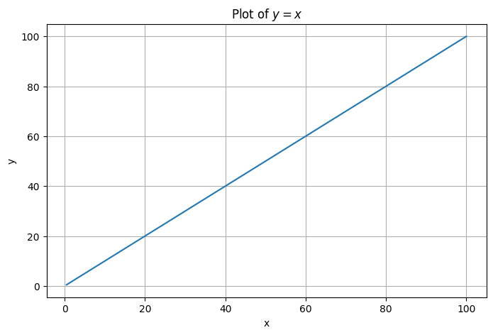

```python
import matplotlib.pyplot as plt
import numpy as np

# Domain: x from 0.5 to 100 in steps of 0.5
x = np.arange(0.5, 100.0 + 0.5, 0.5)

# Function y = x
y = x

# Plot
plt.figure(figsize=(8, 5))
plt.plot(x, y, label=r"$y = x$")
plt.xlabel("x")
plt.ylabel("y")
plt.title(r"Plot of $y = x$")
plt.grid(True)
plt.show()
```

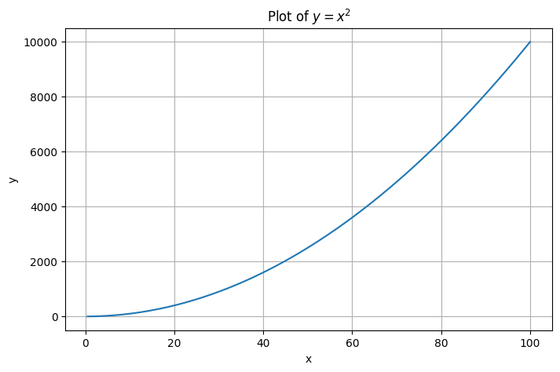

```python
x = np.arange(0.5, 100.0 + 0.5, 0.5)

# Function y = x^2
y = x**2

# Plot
plt.figure(figsize=(8, 5))
plt.plot(x, y, label=r"$y = x^2$")
plt.xlabel("x")
plt.ylabel("y")
plt.title(r"Plot of $y = x^2$")
plt.grid(True)
plt.show()
```

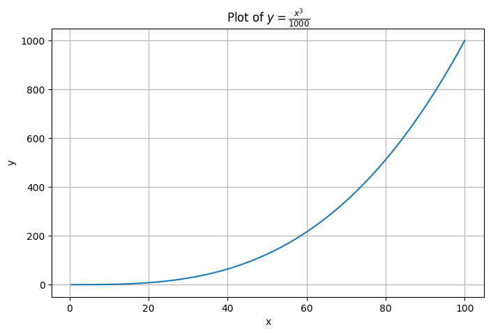

```python
y = x**3 / 1000

# Plot
plt.figure(figsize=(8, 5))
plt.plot(x, y, label=r"$y = \frac{x^3}{1000}$")
plt.xlabel("x")
plt.ylabel("y")
plt.title(r"Plot of $y = \frac{x^3}{1000}$")
plt.grid(True)
plt.show()
```

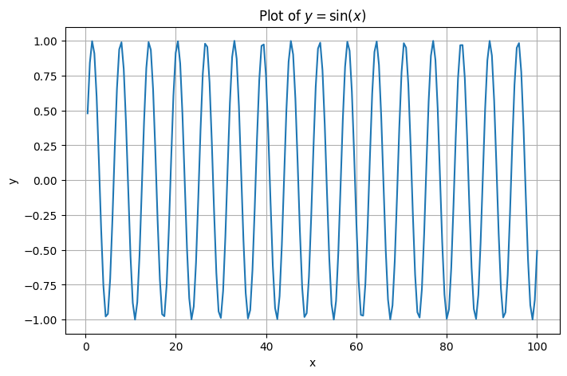

```python
y = np.sin(x)

# Plot
plt.figure(figsize=(8, 5))
plt.plot(x, y, label=r"$y = \sin(x)$")
plt.xlabel("x")
plt.ylabel("y")
plt.title(r"Plot of $y = \sin(x)$")
plt.grid(True)
plt.show()
```

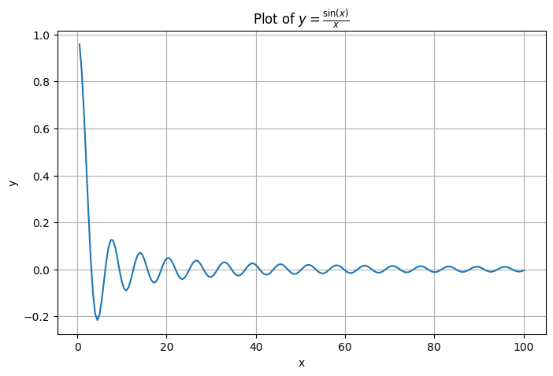

```python
y = np.sin(x) / x

# Plot
plt.figure(figsize=(8, 5))
plt.plot(x, y, label=r"$y = \frac{\sin(x)}{x}$")
plt.xlabel("x")
plt.ylabel("y")
plt.title(r"Plot of $y = \frac{\sin(x)}{x}$")
plt.grid(True)
plt.show()
```

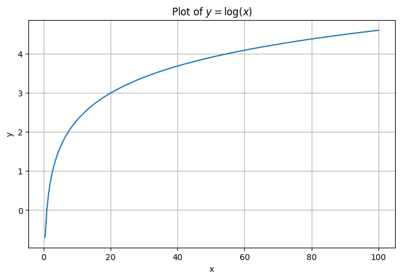

```python
# Function y = log(x)  (natural logarithm)
y = np.log(x)

# Plot
plt.figure(figsize=(8, 5))
plt.plot(x, y, label=r"$y = \log(x)$")
plt.xlabel("x")
plt.ylabel("y")
plt.title(r"Plot of $y = \log(x)$")
plt.grid(True)
plt.show()
```

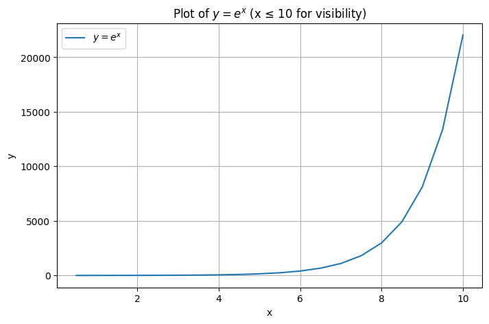

```python
# Function y = e^x
y = np.exp(x)


mask = x <= 10
plt.figure(figsize=(8, 5))
plt.plot(x[mask], y[mask], label=r"$y = e^x$")
plt.xlabel("x")
plt.ylabel("y")
plt.title(r"Plot of $y = e^x$ (x ≤ 10 for visibility)")
plt.legend()
plt.grid(True)
plt.show()
```

### Question 10

#### Using numpy generate a matrix of size 20X5 containing random numbers drawn uniformly from the range of 1 to 2. Using Pandas create a dataframe out of this matrix. Name the columns of the dataframe as “a”, “b”, “c”, “d”, “e”. Find the column with the highest standard deviation. Find the row with the lowest mean.

```python
import pandas as pd


matrix = np.random.uniform(1, 2, size=(20, 5))


df = pd.DataFrame(matrix, columns=["a", "b", "c", "d", "e"])


col_with_max_std = df.std().idxmax()
max_std_value = df.std().max()


row_with_min_mean = df.mean(axis=1).idxmin()
min_mean_value = df.mean(axis=1).min()


print("DataFrame:\n", df)
print(f"\nColumn with highest standard deviation: {col_with_max_std} (Std = {max_std_value:.4f})")
print(f"Row with lowest mean: Row index {row_with_min_mean} (Mean = {min_mean_value:.4f})")
```

```
DataFrame:
            a         b         c         d         e
0   1.577095  1.177931  1.354824  1.591397  1.705823
1   1.010104  1.951074  1.819239  1.949585  1.959047
2   1.023732  1.072979  1.740633  1.694063  1.312151
3   1.039432  1.912228  1.760695  1.252608  1.412611
4   1.895734  1.310596  1.323524  1.773838  1.633668
5   1.883827  1.586797  1.300726  1.228157  1.373347
6   1.455834  1.342804  1.353611  1.818704  1.422842
7   1.317553  1.598907  1.931506  1.100217  1.991605
8   1.829053  1.636093  1.276777  1.736074  1.076285
9   1.987656  1.894337  1.634767  1.600029  1.480357
10  1.830287  1.116020  1.087636  1.442285  1.619461
11  1.014178  1.782085  1.253494  1.771165  1.666914
12  1.752229  1.893713  1.830766  1.045397  1.548034
13  1.226526  1.884688  1.241066  1.538336  1.615991
14  1.590376  1.857876  1.483102  1.905184  1.360051
15  1.819749  1.709606  1.010905  1.021382  1.323549
16  1.126121  1.396960  1.498812  1.846161  1.080919
17  1.052468  1.693994  1.479613  1.736460  1.366083
18  1.960486  1.053109  1.945168  1.973478  1.063288
19  1.058349  1.685795  1.131914  1.392997  1.979149

Column with highest standard deviation: a (Std = 0.3767)
Row with lowest mean: Row index 2 (Mean = 1.3687)
```

### Question 11

#### Add a new column to the dataframe called “f” which is the sum of the columns “a”, “b”, “c”, “d”, “e”. Create another column called “g”. The value in the column “g” should be “LT8” if the value in the column “f” is less than 8 and “GT8” otherwise. Find the number of rows in the dataframe where the value in the column “g” is “LT8”. Find the standard deviation of the column “f” for the rows where the value in the column “g” is “LT8” and “GT8” respectively.

```python
matrix = np.random.uniform(1, 2, size=(20, 5))


df = pd.DataFrame(matrix, columns=["a", "b", "c", "d", "e"])


df["f"] = df[["a", "b", "c", "d", "e"]].sum(axis=1)


df["g"] = np.where(df["f"] < 8, "LT8", "GT8")


lt8_count = (df["g"] == "LT8").sum()


std_lt8 = df[df["g"] == "LT8"]["f"].std()
std_gt8 = df[df["g"] == "GT8"]["f"].std()


print("DataFrame:\n", df)
print("\nNumber of rows where g is LT8:", lt8_count)
print("\nStandard deviation of f for LT8:", std_lt8)
print("Standard deviation of f for GT8:", std_gt8)
```

```
DataFrame:
            a         b         c         d         e         f    g
0   1.045888  1.510456  1.510066  1.719729  1.220353  7.006491  LT8
1   1.128218  1.837118  1.505607  1.854654  1.243715  7.569312  LT8
2   1.463576  1.642103  1.938116  1.740924  1.651428  8.436147  GT8
3   1.455994  1.542370  1.764364  1.970523  1.893286  8.626537  GT8
4   1.018495  1.935759  1.960808  1.284133  1.270083  7.469278  LT8
5   1.596615  1.081421  1.922103  1.188309  1.574196  7.362644  LT8
6   1.096774  1.886081  1.285003  1.615376  1.761410  7.644644  LT8
7   1.615244  1.043026  1.989888  1.450964  1.482067  7.581189  LT8
8   1.304159  1.672673  1.104847  1.858484  1.840792  7.780955  LT8
9   1.261885  1.951266  1.009434  1.376565  1.288233  6.887383  LT8
10  1.253696  1.508581  1.799852  1.618756  1.085601  7.266485  LT8
11  1.969852  1.771854  1.763480  1.615868  1.884996  9.006050  GT8
12  1.563508  1.342777  1.958080  1.594178  1.090926  7.549469  LT8
13  1.176767  1.177212  1.593585  1.093743  1.343239  6.384545  LT8
14  1.078705  1.225870  1.553934  1.057328  1.129913  6.045750  LT8
15  1.961681  1.498331  1.495745  1.216916  1.306832  7.479504  LT8
16  1.637024  1.060084  1.660935  1.267174  1.698821  7.324038  LT8
17  1.087479  1.031924  1.852400  1.538641  1.381219  6.891663  LT8
18  1.161429  1.477158  1.077650  1.779003  1.570003  7.065243  LT8
19  1.625580  1.544670  1.151935  1.896694  1.431231  7.650110  LT8

Number of rows where g is LT8: 17

Standard deviation of f for LT8: 0.4720855223613966
Standard deviation of f for GT8: 0.2901345664154502
```

### Question 12

#### Write a small piece of code to explain broadcasting in numpy

```python
A = np.array([[1, 2, 3],
              [4, 5, 6],
              [7, 8, 9]])


b = np.array([10, 20, 30])


C = A + b

print("Matrix A:\n", A)
print("\nArray b:", b)
print("\nResult after broadcasting (A + b):\n", C)
```

```
Matrix A:
 [[1 2 3]
 [4 5 6]
 [7 8 9]]

Array b: [10 20 30]

Result after broadcasting (A + b):
 [[11 22 33]
 [14 25 36]
 [17 28 39]]
```

### Question 13

#### Write a function to compute the argmin of a numpy array. The function should take a numpy array as input and return the index of the minimum element. You can use the np.argmin function to verify your solution

```python
def my_argmin(arr):

    min_index = 0
    min_value = arr[0]


    for i in range(1, len(arr)):
        if arr[i] < min_value:
            min_value = arr[i]
            min_index = i

    return min_index


arr = np.array([3, 1, 4, 1.5, -2, 7])


my_index = my_argmin(arr)


np_index = np.argmin(arr)

print("Array:", arr)
print("My argmin index:", my_index)
print("NumPy argmin index:", np_index)
```

```
Array: [ 3.   1.   4.   1.5 -2.   7. ]
My argmin index: 4
NumPy argmin index: 4
```